# Statistics Course Week 2

# Week 2

## R Instructions

For this lesson, make sure you have the following packages downloaded and loaded.

```r
install.packages(c("tidyverse", "skimr", "janitor", "gmodels"))
library(skimr)
library(janitor)
library(gmodels)
library(tidyverse)
```

There are several ways to see the variables in your dataset.

By click on the blue circle with an arrow next to the name of your dataset in the “environment” tab, you can see the variable name, the variable type, the values from the first several observations, and any label or format attributes associated with the variable.

You can see the same information in the console window using the `str` function.

```r
str(lesson1a)
```

```
## Classes 'tbl_df', 'tbl' and 'data.frame':    386 obs. of  11 variables:
##  $ id : num  541836 285383 332777 566828 193254 ...
##   ..- attr(*, "format.stata")= chr "%9.0g"
##  $ sex: num  0 1 0 1 1 1 0 0 1 0 ...
##   ..- attr(*, "label")= chr "1 if woman, 0 if man"
##   ..- attr(*, "format.stata")= chr "%9.0g"
##  $ age: num  33 55 52 53 57 31 54 26 52 66 ...
##   ..- attr(*, "format.stata")= chr "%9.0g"
##  $ p1 : num  0 0 0 0 0 0 0 0 0 0 ...
##   ..- attr(*, "label")= chr "pain at time 1 postop"
##   ..- attr(*, "format.stata")= chr "%9.0g"
##  $ p2 : num  0 1 0 0 1 0 1 0 0 1 ...
##   ..- attr(*, "label")= chr "pain at time 2 postop"
##   ..- attr(*, "format.stata")= chr "%9.0g"
##  $ p3 : num  0 1 3 0 2 2 4 1 0 1 ...
##   ..- attr(*, "label")= chr "pain at time 3 postop"
##   ..- attr(*, "format.stata")= chr "%9.0g"
##  $ p4 : num  0 1 3 1 3 2 1 0 0 1 ...
##   ..- attr(*, "label")= chr "pain at time 4 postop"
##   ..- attr(*, "format.stata")= chr "%9.0g"
##  $ t  : num  0 3 6 1 6 4 6 1 0 3 ...
##   ..- attr(*, "label")= chr "total pain score times 1 - 4"
##   ..- attr(*, "format.stata")= chr "%9.0g"
##  $ x  : num  2 2 1 2 2 1 1 1 2 1 ...
##   ..- attr(*, "format.stata")= chr "%9.0g"
##  $ y  : chr  "campus" "campus" "campus" "campus" ...
##   ..- attr(*, "format.stata")= chr "%9s"
##  $ z  : num  1 1 NA NA 1 3 1 1 3 1 ...
##   ..- attr(*, "format.stata")= chr "%9.0g"
```

The commands you might think about using for the data sets sent after lecture 2 are given below. I give examples from lesson1a.rds, the data I sent after lecture 1.

### Summarizing continuous variables

The function `skim` will give summary statistics for specified variables.

```r
lesson1a %>% skim(age)
```

```
## Skim summary statistics
##  n obs: 386
##  n variables: 11
##
## -- Variable type:numeric ---------------------------------------------------------
##  variable missing complete   n  mean    sd p0 p25 p50 p75 p100     hist
##       age       0      386 386 49.48 13.75 19  40  49  59   86 ▂▅▇▇▆▅▂▁
```

So you can tell you have data on age for 386 patients (“obs” standards for “observations”), the mean age was 49 years, standard deviation of the mean was 13.8.

The numbers below `p0`, `p25`, `p50`, `p75` and `p100` are the centiles. `p0` indicates the minimum value, and `p100` indicates the maximum value, so you can tell that the youngest patient was 19 and the oldest was 86. `p50` is the median (49 years), and the interquartile range is reported under `p25` and `p75` (40, 59).

```r
lesson1a %>%
  group_by(sex) %>%
  skim(age)
```

```
## Skim summary statistics
##  n obs: 386
##  n variables: 11
##  group variables: sex
##
## -- Variable type:numeric ---------------------------------------------------------
##  sex variable missing complete   n  mean    sd p0 p25 p50 p75 p100
##    0      age       0      181 181 49.07 13.61 19  40  49  58   82
##    1      age       0      205 205 49.85 13.9  21  40  49  60   86
##      hist
##  ▂▃▇▇▆▅▂▂
##  ▂▆▇▇▆▆▂▁
```

The `group_by` function allows you to group your data and perform analyses separately group. For example, the above code groups by sex, so the mean, standard deviation and other summary statistics are presented separately among men and among women.

### Centiles

You can get R to give you centiles directly by using the `quantile` function. The option `na.rm = TRUE` tells R to ignore any missing (NA) values when calculating the centiles.

```r
quantile(lesson1a$age, na.rm = TRUE)
```

```
##   0%  25%  50%  75% 100%
##   19   40   49   59   86
```

The first row of the results says that you are looking at the 0, 25, 50, 75, and 100 centiles, i.e. the minimum and maximum, and the medium and quartiles. The second row gives you the actual values. So you could report this as “Median age was 49 (quartiles 40, 59).”

You aren’t restricted to quartiles with the `quantile` function. For example, you can use the code below to give you the 11th, 45th and 78th centile, as well as 91.5 centile, which would be the 915th highest value in a dataset of 1000 observations.

```r
quantile(lesson1a$age, probs = c(0.11, 0.45, 0.78, 0.915), na.rm = TRUE)
```

```
##   11%   45%   78% 91.5%
##  32.0  47.0  60.3  69.0
```

### One-way tables

The `tabyl` function (from the `janitor` package) gives a frequency table, in this case, the number of men and women.

```r
tabyl(lesson1a$sex)
```

```
##  lesson1a$sex   n   percent
##             0 181 0.4689119
##             1 205 0.5310881
```

### Two-way tables

The `tabyl` function can also give a two-way table, for example, a table that shows where operations were done (remember that the variable `y` gives the part of the hospital) in men and women separately.

```r
tabyl(lesson1a, sex, y)
```

```
##  sex campus harding peds satellite
##    0    115      15   19        32
##    1    125      24   21        35
```

This shows that, for example, there were 240 operations done at the main campus, 115 of these were done on men and 125 on women.

The `adorn_percentages` function can be added to show the percentage of men who had operations at each site and the percentage of women who had operations at each site. The additional function `adorn_pct_formatting` allows us to format how the percentages are displayed. In this case, `digits = 2` is used so that the percentages are displayed on a scale of 0-100 with two digits after the decimal place.

```r
lesson1a %>%
  tabyl(sex, y) %>%
  adorn_percentages("row") %>%
  adorn_pct_formatting(digits = 2)
```

```
##  sex campus harding   peds satellite
##    0 63.54%   8.29% 10.50%    17.68%
##    1 60.98%  11.71% 10.24%    17.07%
```

This shows that, for example, 8% of men and 12% of women had operations at the “Harding” site, and that, in total, 10% of operations were done at this site.

You can use `adorn_percentages("col")` to get the percentage of operations at each site that were for men and women. `adorn_totals(c("row", "col"))` will also show us the percentage of men and women treated across all sites.

```r
lesson1a %>%
  tabyl(sex, y) %>%
  adorn_totals(c("row", "col")) %>%
  adorn_percentages("col") %>%
  adorn_pct_formatting(digits = 2)
```

```
##    sex  campus harding    peds satellite   Total
##      0  47.92%  38.46%  47.50%    47.76%  46.89%
##      1  52.08%  61.54%  52.50%    52.24%  53.11%
##  Total 100.00% 100.00% 100.00%   100.00% 100.00%
```

This shows that 48% of the operations at the satellite were on men and 52% on women. Overall (look in the “total” column), 47% of the patients treated in the hospital were men and 53% women.

The `count` function with no options will count the number of total observations.

```r
# Count all patients in the dataset
lesson1a %>% count()
```

```
## # A tibble: 1 x 1
##       n
##   <int>
## 1   386
```

The `filter` function allows you to subset groups of data. The `filter` function takes a condition, similar to an `if_else` statement. However, `filter` only keeps observations in the data that meet that condition.

For example, we can use `filter` to count the number of women in the dataset, or the number of operations on women at the main campus. Don’t forget that you need to use two equals signs here.

```r
# Count the number of women
lesson1a %>%
  filter(sex == 1) %>%
  count()
```

```
## # A tibble: 1 x 1
##       n
##   <int>
## 1   205
```

```r
# Count the number of women treated at the main campus
lesson1a %>%
  filter(sex == 1 & y == "campus") %>%
  count()
```

```
## # A tibble: 1 x 1
##       n
##   <int>
## 1   125
```

Note that because we did not use `lesson1a <-` to save these datasets, we did not alter our original dataset. You can use the `count` function to confirm that `lesson1a` still contains all observations.

By the way, try `lesson1a %>% tabyl(age)` and see why continuous data are not summarized by tables!

### Graphing

We won’t be doing much on the graphical presentation of data in this course (this has been called “graphicacy”). The only reason we are doing it here is to get a visual impression of whether data are normally presented (not something you’d want to publish).

The following might sound a little complicated, but just follow it through and everything will be fine.

First, run the following code.

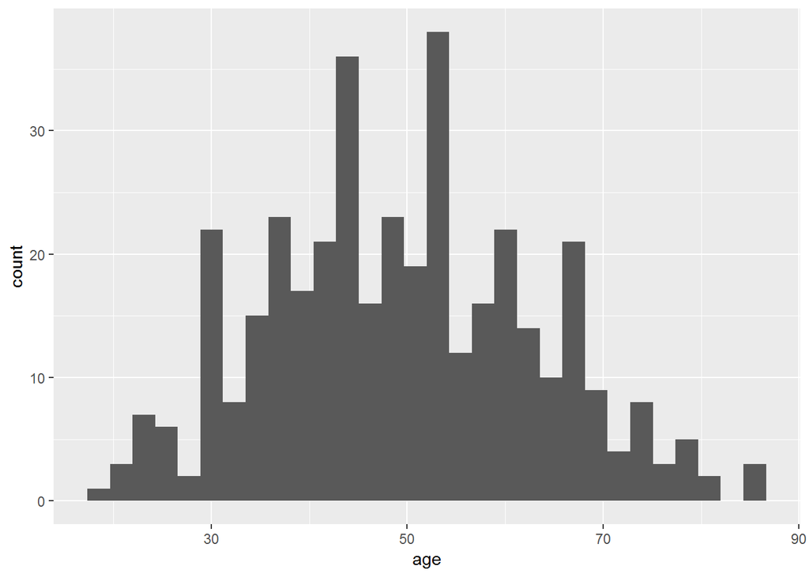

```r
ggplot(data = lesson1a,
       aes(x = age)) +
  geom_histogram()
```

`ggplot` indicates that you want to create a graph. The dataset `lesson1a` is specified in the `data` option, and `aes(x = age)` means that the variable on the x-axis should be age. `geom_histogram` takes this data and graphs it as a histogram.

One of things that R does is to choose the number of bars for you. You can set this yourself by using the `bins` option. Try setting the number of bins to 40.

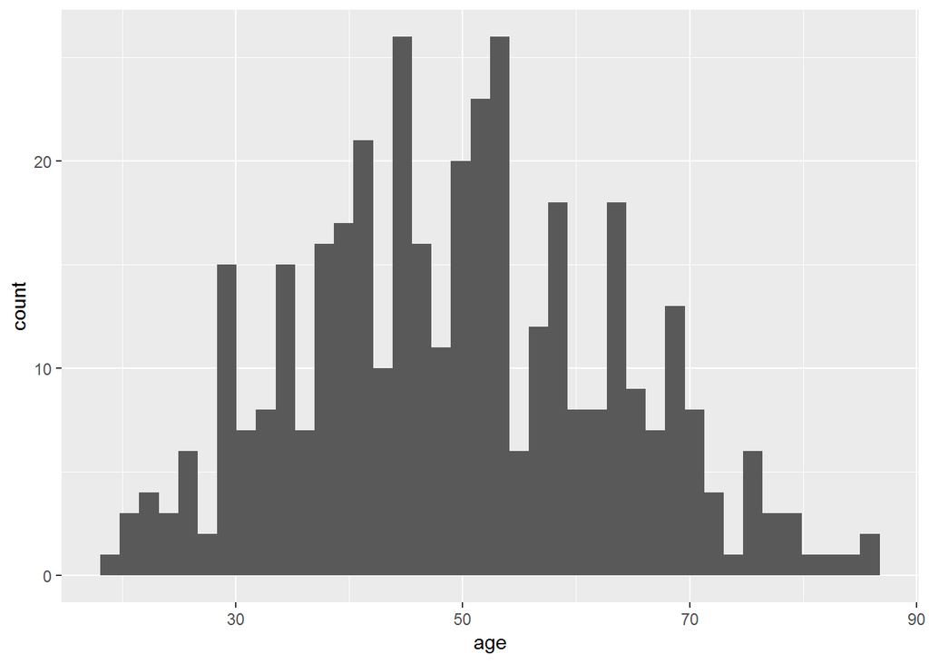

```r
ggplot(data = lesson1a,
       aes(x = age)) +
  geom_histogram(bins = 40)
```

The graph looks “lumpy” because you are breaking the data up into too many small pieces.

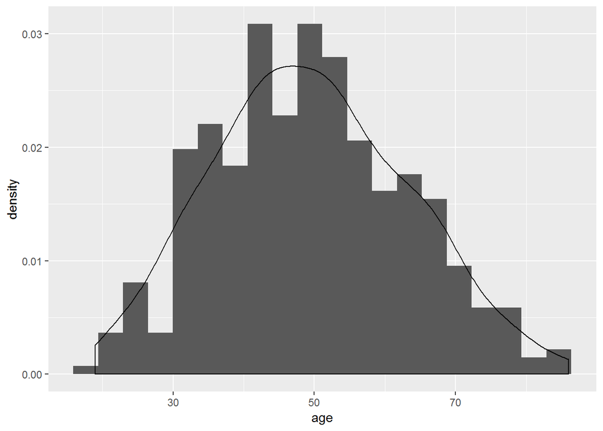

```r
ggplot(data = lesson1a,
       aes(x = age)) +
  geom_histogram(aes(y = ..density..), bins = 20) +
  geom_density()
```

### Further Reading

Only read this if you are feeling really keen…

```r
gmodels::ci(lesson1a$age, confidence = 0.90, na.rm = TRUE)
```

```
##   Estimate   CI lower   CI upper Std. Error
## 49.4844560 48.3301266 50.6387853  0.7000938
```

This gives the mean of age, its standard error and its 90% confidence interval (I’ll explain confidence intervals next week: one thing you might want to think about is to compare the two numbers given for the confidence interval with the 5% and 95% centile using `quantile(lesson1a$age)`).

```r
gmodels::ci.binom(lesson1a$sex, na.rm = TRUE)
```

```
##       Estimate  CI lower  CI upper Std. Error
## [1,] 0.5310881 0.4799345 0.5817614 0.02540009
```

For a binary variable, the function `gmodels::ci.binom` is used. This gives the proportion of women along with 95% confidence intervals (95% is the default, meaning if you don’t specify a level, it assumes you want the 95% confidence interval.)

### Using R as a calculator

R can be used as a calculator:

```r
7*7
```

```
## [1] 49
```

`log()` is the natural logarithm (to base e)

```r
log(2.71828)
```

```
## [1] 0.9999993
```

```r
exp(1)
```

```
## [1] 2.718282
```

`log10()` gives the log to base 10

```r
log10(100)
```

```
## [1] 2
```

`cos(45)` gives the cosine of 45

```r
cos(45)
```

```
## [1] 0.525322
```

Some of the functions give useful statistical constants.

`pnorm(x)` gives the probability that an observation will be less than mean + `x` standard deviations.

```r
pnorm(1)
```

```
## [1] 0.8413447
```

```r
pnorm(-0.5)
```

```
## [1] 0.3085375
```

`pnorm(1)` gives 0.84 - this means that 84% of a normally distributed set of data will be less than one standard deviation above the mean.

`pnorm(-0.5)` gives 0.31, meaning that 31% of a normally distributed set of data will be less than half a standard deviation below the mean.

Iif you had a pain score with a mean of 5 and a standard deviation of 2, you could predict that only 16% of patients would have pain scores of 7 or more and that 70% would have pain scores of 4 or more.

```r
pnorm(1.96)
```

```
## [1] 0.9750021
```

```r
pnorm(-1.96)
```

```
## [1] 0.0249979
```

`pnorm(1.96)` gives 0.975 and `pnorm(-1.96)` gives 0.025. So 97.5% of observations are less than 1.96 standard deviations greater than the mean, and 2.5% are less than 1.96 standard deviations lower than the mean. In other words, 95% of observations are within 1.96 standard deviations of the mean.

## Assignment

It seems like a lot of them, but the task shouldn’t take you very long. However, a general rule in this class is: you don’t have to do all the questions in the assignment. Try to do at least some (say, at least 2a and 2b), so that you know what we are talking about next week in class. Also, the more you do the more you’ll learn. However, don’t drive yourself crazy trying to get them all done.

I am phrasing the questions in ordinary English, pretty much as you would do if you were an investigator. For example, I ask you to summarize the data on race time in marathon runners, rather than say: “provide the mean of the variable `rt` by typing `skim(lesson2a$rt)`”. But this means you are going to have to work out what the various variable codes are and what commands to use.

All of these questions ask you to “summarize” data. In other words, how would you describe the data in a journal article (say, your table 1)? One quick clue here: I don’t ever want the standard error, we’ll talk more about that next week.

### Assignment Data

- lesson2a.rds: This is data from marathon runners: summarize age, sex, race time in minutes (i.e. how long it took them to complete the race) and favorite running shoe
- lesson2b.rds: Postoperative pain (this is a similar data set as you had before for the assignment for the first class). Summarize average pain after the operation. Imagine you had to draw a graph of “time course of pain after surgery”. What numbers would you use for pain at time 1, time 2, time 3 etc.?
- lesson2c.rds: This is data on 242 patients undergoing radical prostatectomy. Summarize age, stage, grade and PSA.
- lesson2d.rds: Cost of a minor medical procedure. Summarize cost.
- lesson2e.rds: Total cancer pain in one month in a group with chronic cancer pain. Summarize pain scores and number of days with pain.